# R Wheel Running Analysis

## Welcome!

This is a Quarto document built to help you analyze .log files from mouse wheel running experiments.

## How to use this notebook:

1. Set your ⚙️ options for analysis
2. Run code chunks 1-3 to set up and create your folder structure.
3. Dump all the .log files in the folder created by the script in `data` > `01_Raw_data`.
4. Then run the remaining code chunks in order.
5. To run everything at once and produce a nice HTML output, Click the **Render** button above

When you execute code within the notebook, the results appear beneath the code. You can run code chunks one by one by clicking the *Run* button in the upper right corner of the chunk or by placing your cursor the code chunk and pressing *Ctrl+Shift+Enter*. To run all code chunks, you can *Ctrl+Alt+R* or hit the Run button and select “Run All” or “Restart R and Run all.”

### 📚 Setup Libraries

This code block loads necessary libraries and sets up the directory structure necessary for the project. You need to run it, but it is not included in your output notebook.

```
here() starts at C:/Users/Rebecca/Documents/GitHub/Mouse-Wheel-Running-Analysis
```

[output not shown]

### ⚙️ Options for analysis – USER INPUT REQUIRED

- Select your options for your analysis in the code below. `TRUE` for True, `FALSE` for False.

```
Settings for Exp1 :
      Experiment name : Exp1
           Lights On  : 7
           Lights Off : 19
 Time change?️ : TRUE
```

```
Time change settings:️
        Day of change : 14
           Lights ON  : 7  --> 7
           Lights OFF : 19 --> 12
```

```
  ~ DONE! ~  02. Settings loaded!
```

### 📁 Make directory structure for the project

```
 ~ DONE! ~ 3. Made folder structure here: 📂 C:/Users/Rebecca/Documents/GitHub/Mouse-Wheel-Running-Analysis
```

### 🧹 Organize, Load, and Clean Data

This step organizes the mouse .log files into 1 folder per mouse, then loads the data into R and creates a metadata table from the data frames.

If you’d like to remove animals, now is the time to remove those folders from data > 02_Organized_data.

### 🔢 Add columns to data

This chunk takes your data for each mouse and adds additional variables, like speed, time of day, and experimental phase information. Data columns include:

- `expDay` (1, 2, 3…# of experimental days)
- `speed` (should be in meters/min)
- `elapsedDays` same as `expDay` but days can be fractional
- `hour` (clock time hour)
- `minutes` (clock time minutes)
- `activeFactor` (whether the animal is in its active phase (lights OFF -> TRUE))
- `t` (time in seconds since the first lights ON (can precede the start of the recording, usually this is lights on on Day 1)
- `expPhase` (which experimental phase each time point belongs to)
- `moving` (whether that individual animal moved during that 10 second period))

Now we stitch everything together into 1 big data table. We additionally add an `id` variable for each experimental mouse that is the mouse ID + the experiment name.

behavr table with: 24 individuals 7 metavariables 10 variables 7.197168e+06 measurements 1 key (id)

~ DONE! ~ 7. 2 mice were removed because they ran **less than 1%** of the experiment: ❌ M01-C01-376R ❌ M03-C01-379R

### 📆 Experimental timeline

Now we add in the different phases of the experiment in a `expPhase` column.

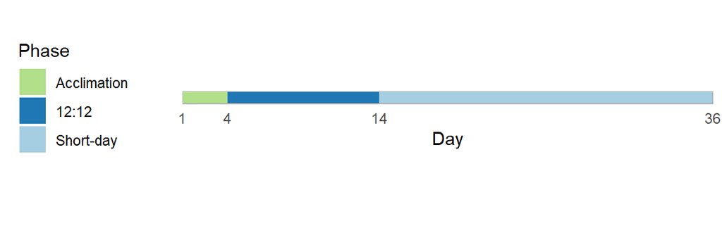

```
~ DONE! ~ 8. Phase information added to data table. 📋
```

### 💾 Save tables

This is optional, if you want to save out tables of binned data for each mouse.

```r
# Would you like to save data every X min? (default True)
saveBinned <- TRUE
desired_bin <- 5 # min

#######################
#Save Metadata table
write.csv(full_metadata, file=here(dir_results, "exp_metdata.csv"))


#Save daily and light cycle data for every mouse
  dt_daily_byLC <- dt %>% dplyr::group_by(id, expDay, activeFactor) %>% dplyr::summarize(avg_speed = mean(speed))
    filename <- paste0(expName,"_daily_bylightcycle.csv")
    write.csv(dt_daily_byLC, file=here(dir_results, filename), row.names = FALSE)

#Save just daily data for every mouse
  dt_daily <- dt %>% dplyr::group_by(id, expDay) %>% dplyr::summarize(avg_speed = mean(speed))
```

[output not shown]

```r
    filename <- paste0(expName,"_daily.csv")
    write.csv(dt_daily, file=here(dir_results, filename), row.names = FALSE)
  cat(cmark, paste0('9. Finished summarizing daily data for ',nMice,' mice '), '🐁')
```

```
~ DONE! ~ 9. Finished summarizing daily data for 24 mice  🐁
```

```r
if (saveBinned){
  pb <- progress_bar$new(total=nMice)
for (eachid in metadata[,id]){
  df <- full_dt[id==eachid,]
  mouse <- sub("\\|.*", "", eachid)
  t_min <- min(df$t)/behavr::mins(1)
  t_max <- max(df$t)/behavr::mins(1)
  df <- data.frame("MeanSpeed"=tapply(df$speed, cut(df$t/behavr::mins(1), seq(t_min, t_max, by=desired_bin)), mean), "ExpDay"=tapply(df$expDay, cut(df$t/behavr::mins(1), seq(t_min, t_max, by=desired_bin)), median))
  filename <- paste0(mouse,"_",desired_bin,"_min.csv")
  write.csv(df, file=here(dir_table_ind, filename), row.names = F)
  pb$tick()
}

cat('\n', cmark, '9. Finished collapsing data into ',desired_bin,' minute bins (function = mean) for ',nMice,' mice ', '🐁')
}
```

```
 ~ DONE! ~ 9. Finished collapsing data into  5  minute bins (function = mean) for  24  mice  🐁
```

```r
#remove(full_dt)
startDay <- 1
endDay <- max(dt$expDay)
```

### 📈 Make graphs

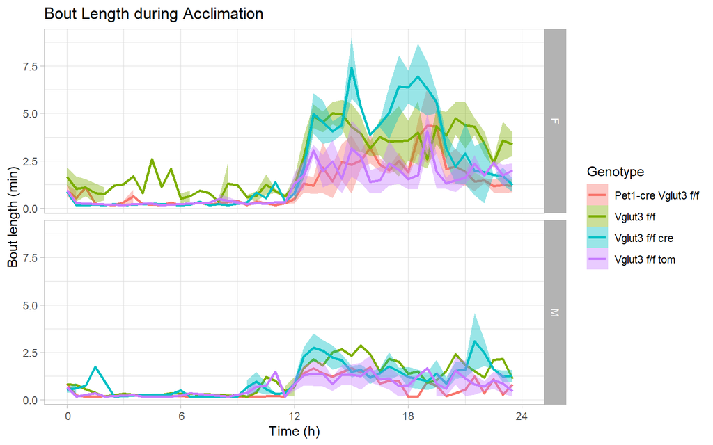

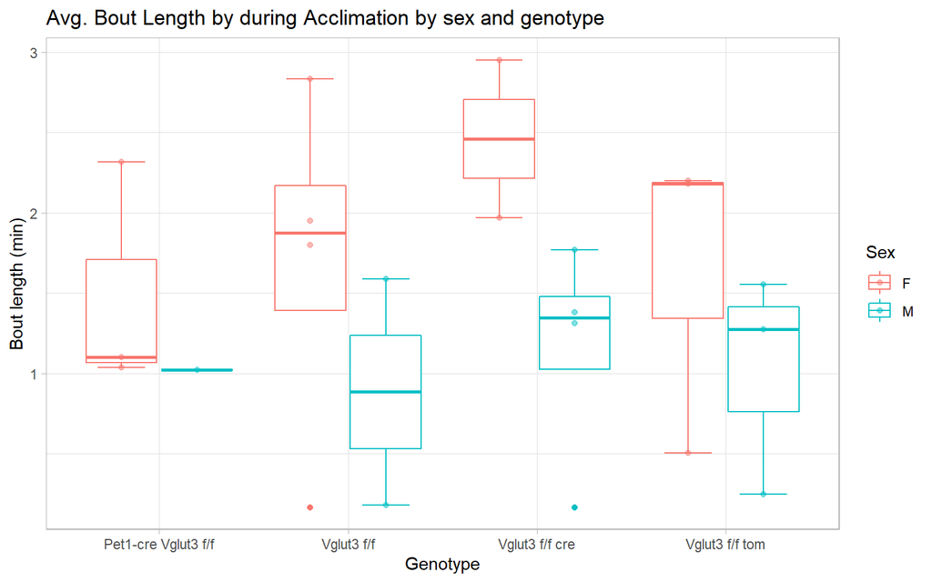

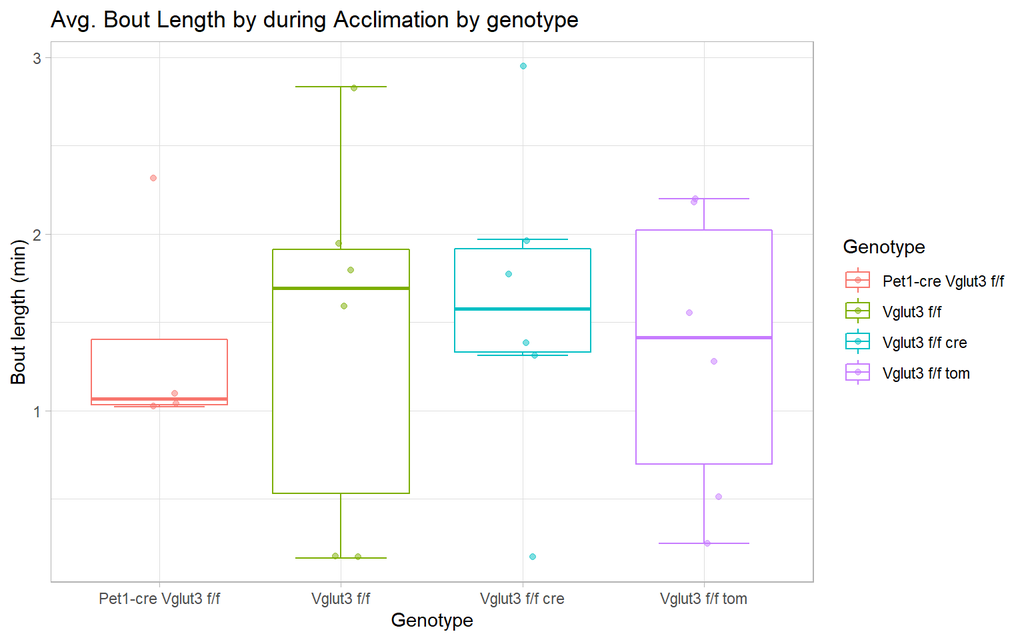

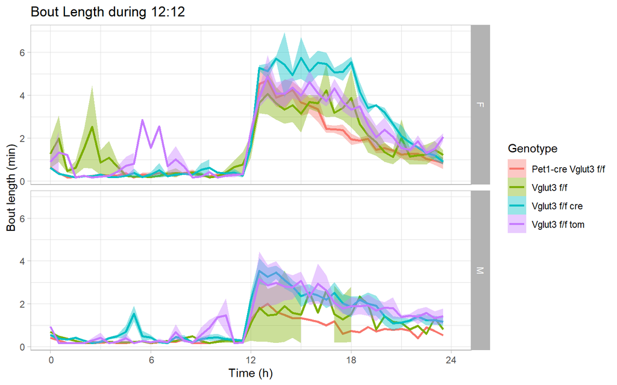

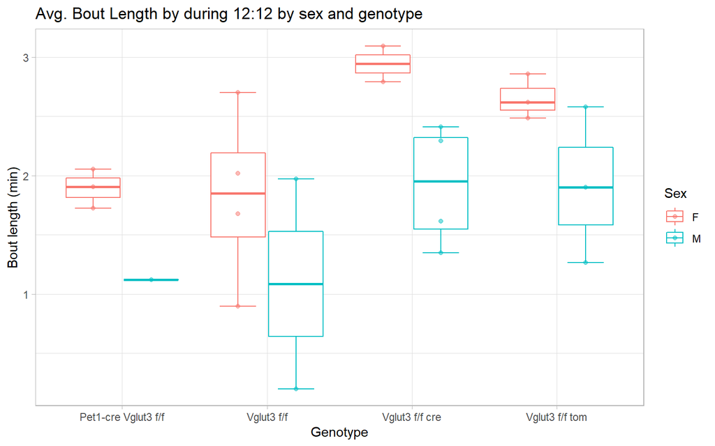

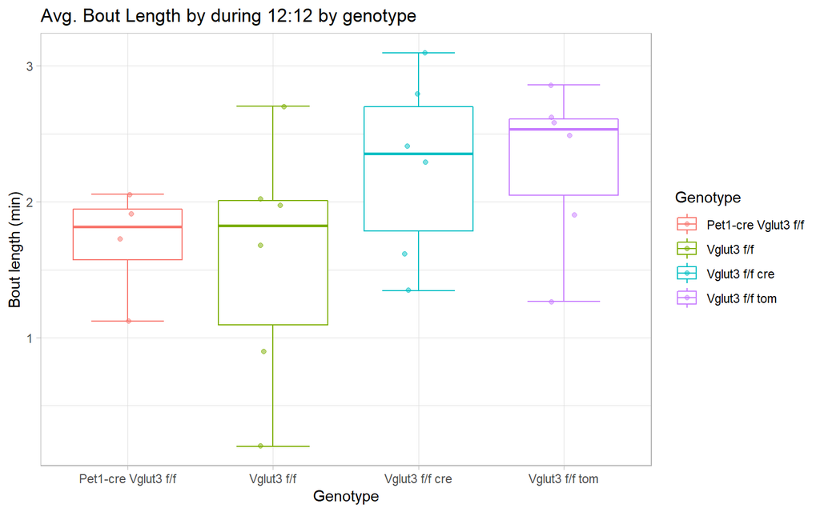

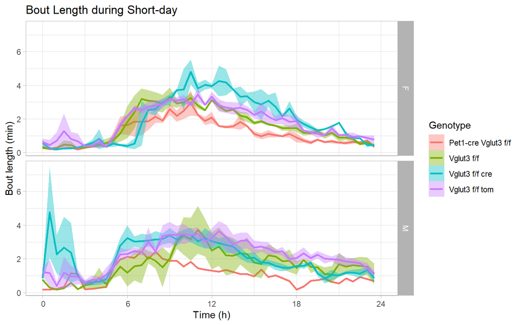

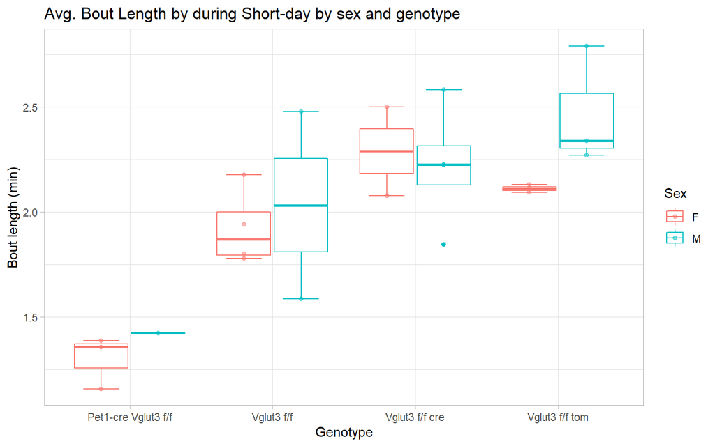

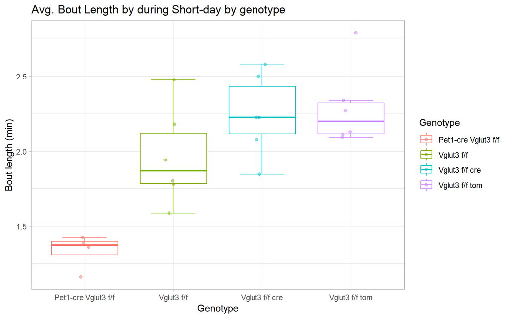

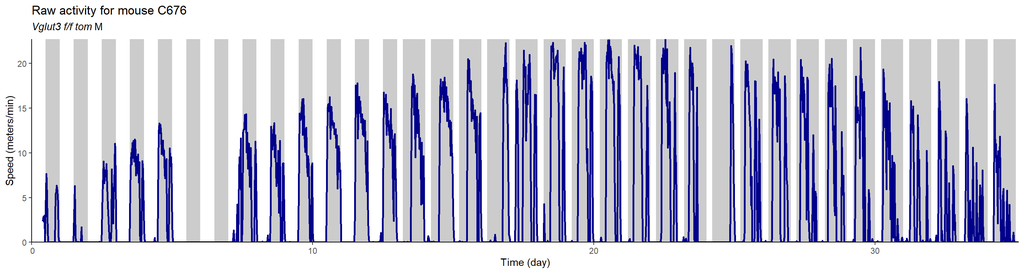

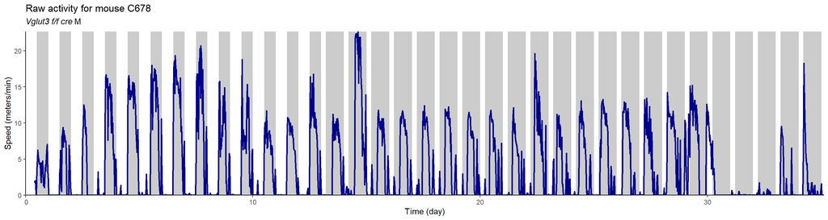

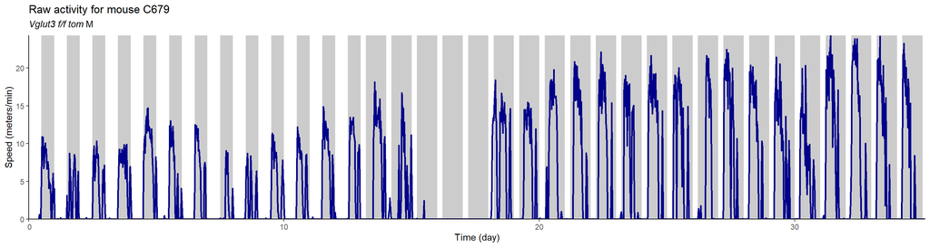

[22 more figures not shown]

#### Actogram graph for all mice

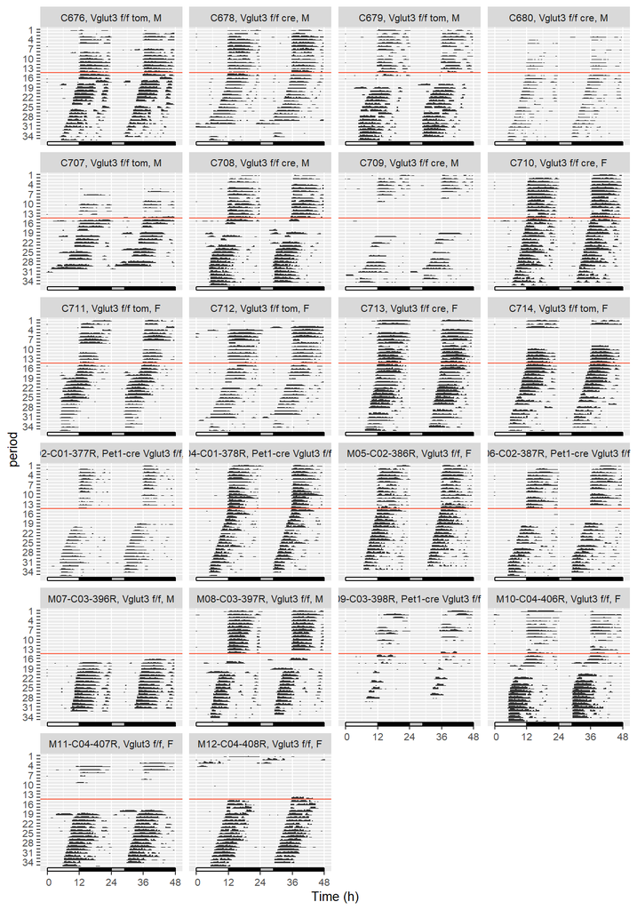

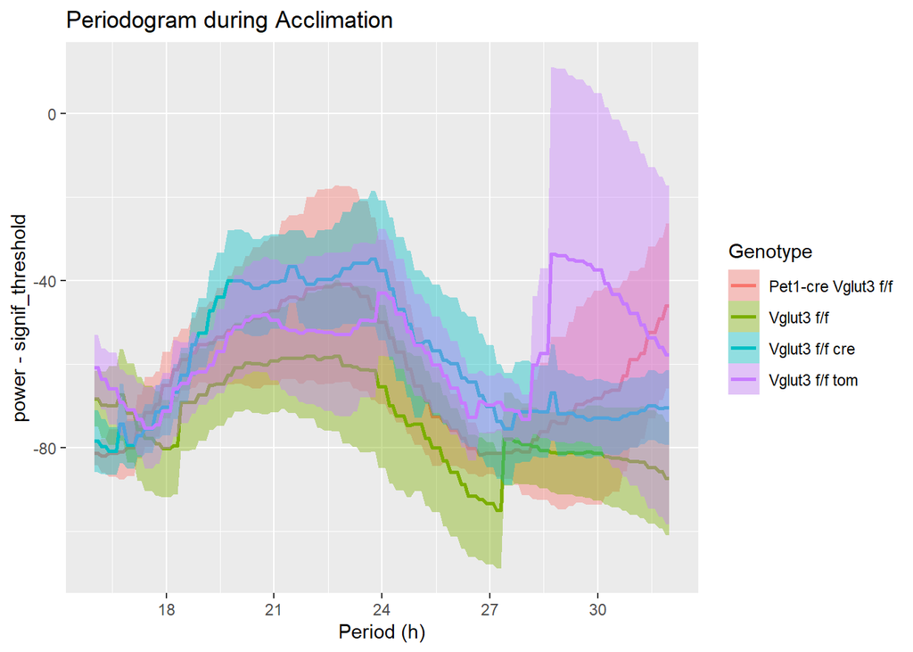

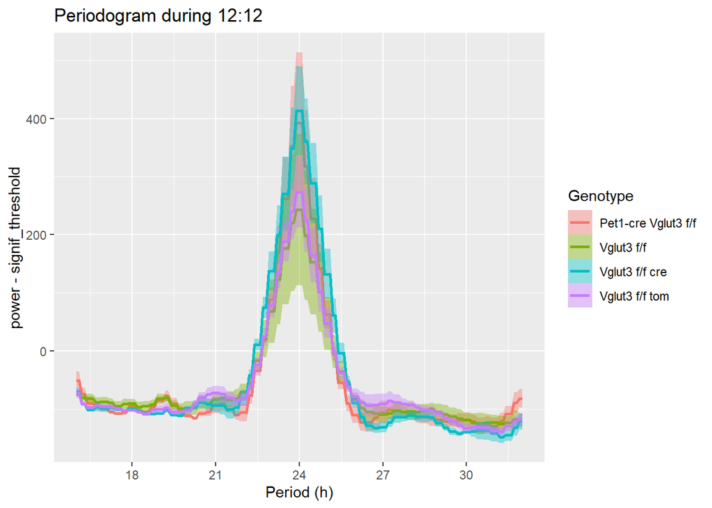

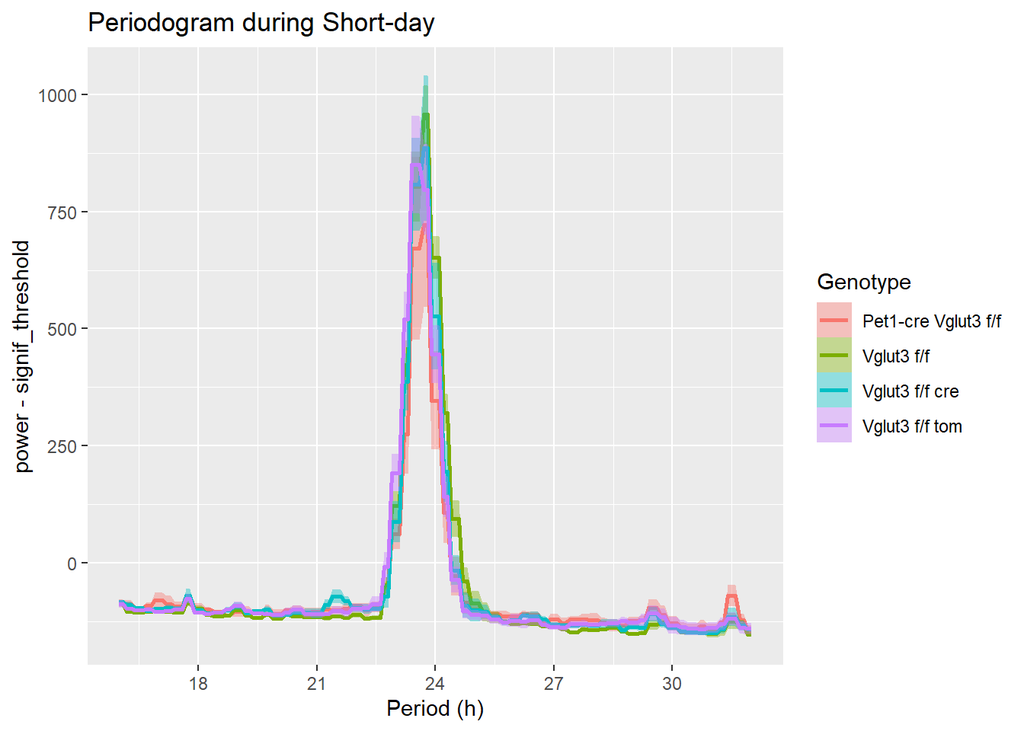

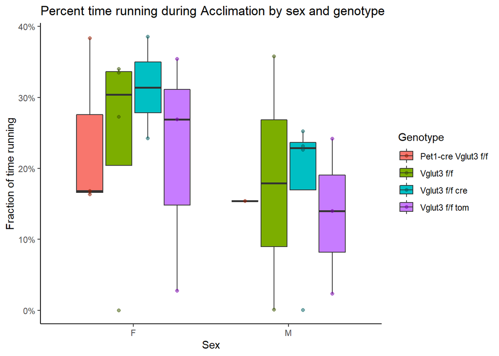

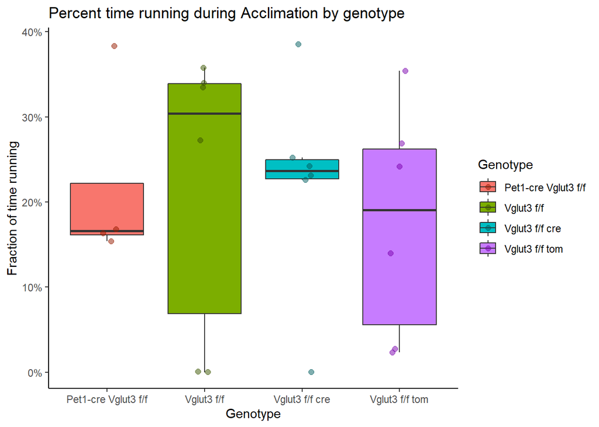

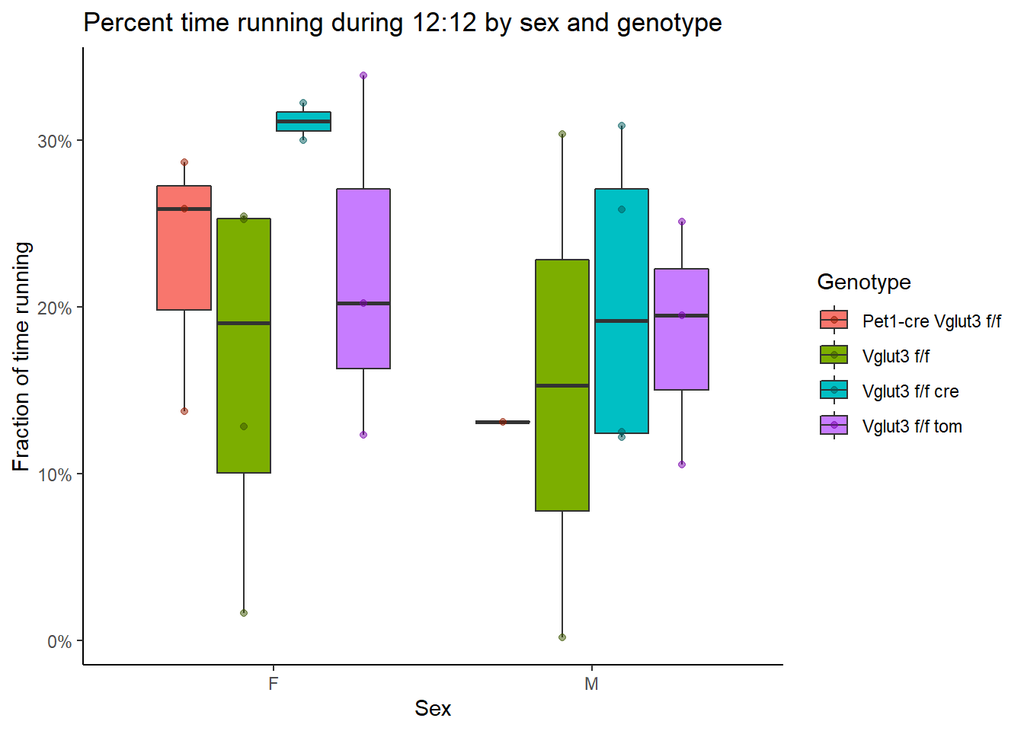

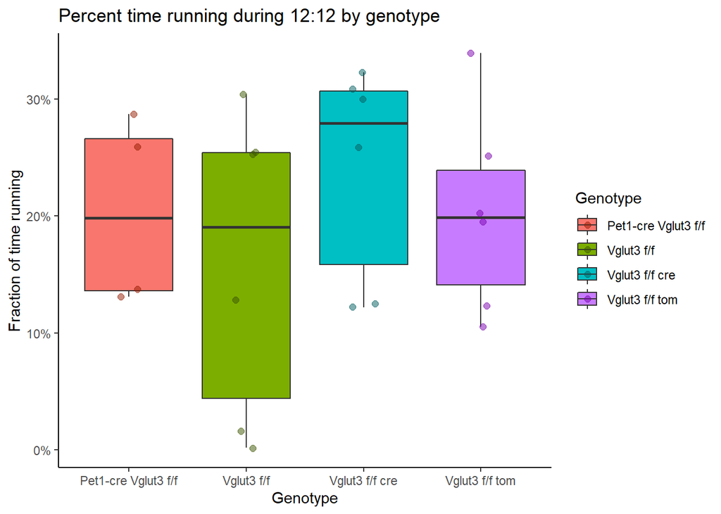

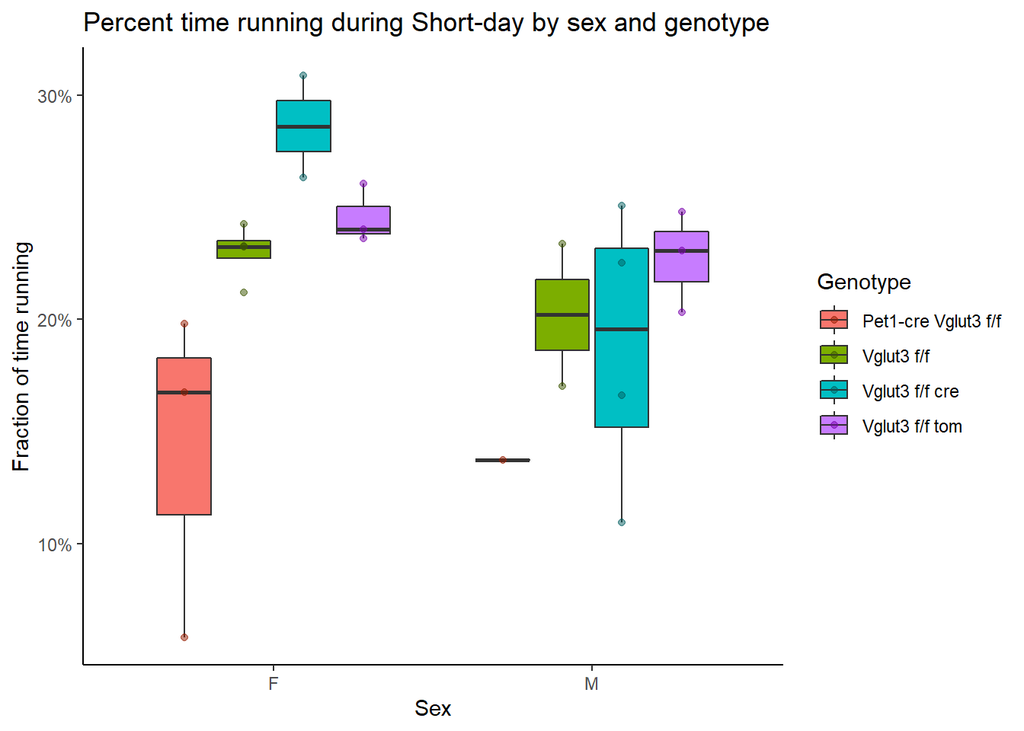

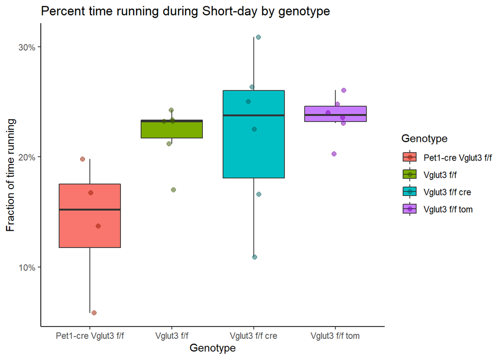

### 📑 Methods and References

Analyses were conducted using the R Statistical language (version 4.0.2; R Core Team, 2020) on Windows 10 x64 (build 22000), using the packages progress (version 1.2.2; Gábor Csárdi and Rich FitzJohn, 2019), ggplot2 (version 3.3.5; Wickham. ggplot2: Elegant Graphics for Data Analysis. Springer-Verlag New York, 2016.), reshape2 (version 1.4.4; Hadley Wickham, 2007), stringr (version 1.4.0; Hadley Wickham, 2019), tidyr (version 1.2.0; Hadley Wickham and Maximilian Girlich, 2022), dplyr (version 1.0.8; Hadley Wickham et al., 2022), matrixStats (version 0.61.0; Henrik Bengtsson, 2021), fs (version 1.5.2; Jim Hester, Hadley Wickham and Gábor Csárdi, 2021), vroom (version 1.5.7; Jim Hester, Hadley Wickham and Jennifer Bryan, 2021), here (version 1.0.1; Kirill Müller, 2020), report (version 0.5.1; Makowski et al., 2020), data.table (version 1.14.2; Matt Dowle and Arun Srinivasan, 2021), sleepr (version 0.3.0; Quentin Geissmann, 2018), behavr (version 0.3.2; Quentin Geissmann, 2019), ggetho (version 0.3.6; Quentin Geissmann, 2020), zeitgebr (version 0.3.5; Quentin Geissmann and Luis Garcia, 2020) and colorspace (version 2.0.3; Zeileis A et al., 2020).

## References

- Gábor Csárdi and Rich FitzJohn (2019). progress: Terminal Progress Bars. R package version 1.2.2. https://CRAN.R-project.org/package=progress
- H. Wickham. ggplot2: Elegant Graphics for Data Analysis. Springer-Verlag New York, 2016.
- Hadley Wickham (2007). Reshaping Data with the reshape Package. Journal of Statistical Software, 21(12), 1-20. URL http://www.jstatsoft.org/v21/i12/.
- Hadley Wickham (2019). stringr: Simple, Consistent Wrappers for Common String Operations. R package version 1.4.0. https://CRAN.R-project.org/package=stringr
- Hadley Wickham and Maximilian Girlich (2022). tidyr: Tidy Messy Data. R package version 1.2.0. https://CRAN.R-project.org/package=tidyr
- Hadley Wickham, Romain François, Lionel Henry and Kirill Müller (2022). dplyr: A Grammar of Data Manipulation. R package version 1.0.8. https://CRAN.R-project.org/package=dplyr
- Henrik Bengtsson (2021). matrixStats: Functions that Apply to Rows and Columns of Matrices (and to Vectors). R package version 0.61.0. https://CRAN.R-project.org/package=matrixStats
- Jim Hester, Hadley Wickham and Gábor Csárdi (2021). fs: Cross-Platform File System Operations Based on ‘libuv’. R package version 1.5.2. https://CRAN.R-project.org/package=fs
- Jim Hester, Hadley Wickham and Jennifer Bryan (2021). vroom: Read and Write Rectangular Text Data Quickly. R package version 1.5.7. https://CRAN.R-project.org/package=vroom
- Kirill Müller (2020). here: A Simpler Way to Find Your Files. R package version 1.0.1. https://CRAN.R-project.org/package=here
- Makowski, D., Ben-Shachar, M.S., Patil, I. & Lüdecke, D. (2020). Automated Results Reporting as a Practical Tool to Improve Reproducibility and Methodological Best Practices Adoption. CRAN. Available from https://github.com/easystats/report. doi: .
- Matt Dowle and Arun Srinivasan (2021). data.table: Extension of `data.frame`. R package version 1.14.2. https://CRAN.R-project.org/package=data.table
- Quentin Geissmann (2018). sleepr: Analyse Activity and Sleep Behaviour. R package version 0.3.0. https://CRAN.R-project.org/package=sleepr
- Quentin Geissmann (2019). behavr: Canonical Data Structure for Behavioural Data. R package version 0.3.2. https://CRAN.R-project.org/package=behavr
- Quentin Geissmann (2020). ggetho: Visualisation of High-Throughput Behavioural (i.e. Ethomics) Data. R package version 0.3.6. https://CRAN.R-project.org/package=ggetho
- Quentin Geissmann and Luis Garcia (2020). zeitgebr: Analysis of Circadian Behaviours. R package version 0.3.5. https://CRAN.R-project.org/package=zeitgebr
- R Core Team (2020). R: A language and environment for statistical computing. R Foundation for Statistical Computing, Vienna, Austria. URL https://www.R-project.org/.
- Zeileis A, Fisher JC, Hornik K, Ihaka R, McWhite CD, Murrell P,Stauffer R, Wilke CO (2020). “colorspace: A Toolbox for Manipulatingand Assessing Colors and Palettes.” *Journal of Statistical Software*,*96*(1), 1-49. doi: 10.18637/jss.v096.i01 (URL:https://doi.org/10.18637/jss.v096.i01).

Session info for configuration

R version 4.0.2 (2020-06-22) Platform: x86_64-w64-mingw32/x64 (64-bit) Running under: Windows 10 x64 (build 22000)

Matrix products: default

locale: [1] LC_COLLATE=English_United States.1252 [2] LC_CTYPE=English_United States.1252  
[3] LC_MONETARY=English_United States.1252 [4] LC_NUMERIC=C  
[5] LC_TIME=English_United States.1252

attached base packages: [1] grid stats graphics grDevices utils datasets methods  
[8] base

other attached packages: [1] zeitgebr_0.3.5 sleepr_0.3.0 report_0.5.1 ggetho_0.3.6  
[5] behavr_0.3.2 ggplot2_3.3.5 data.table_1.14.2 progress_1.2.2  
[9] fs_1.5.2 vroom_1.5.7 dplyr_1.0.8 reshape2_1.4.4  
[13] matrixStats_0.61.0 stringr_1.4.0 here_1.0.1 tidyr_1.2.0  
[17] colorspace_2.0-3

loaded via a namespace (and not attached): [1] tidyselect_1.1.2 xfun_0.30 purrr_0.3.4 archive_1.1.4  
[5] vctrs_0.3.8 generics_0.1.2 htmltools_0.5.2 yaml_2.3.5  
[9] pracma_2.3.8 utf8_1.2.2 rlang_1.0.2 pillar_1.7.0  
[13] glue_1.6.2 withr_2.5.0 RColorBrewer_1.1-3 bit64_4.0.5  
[17] lifecycle_1.0.1 plyr_1.8.7 munsell_0.5.0 gtable_0.3.0  
[21] htmlwidgets_1.5.4 evaluate_0.15 labeling_0.4.2 knitr_1.38  
[25] tzdb_0.3.0 fastmap_1.1.0 parallel_4.0.2 datawizard_0.4.1  
[29] fansi_1.0.3 Rcpp_1.0.8.3 scales_1.2.0 jsonlite_1.8.0  
[33] farver_2.1.0 bit_4.0.4 hms_1.1.1 digest_0.6.25  
[37] stringi_1.7.6 insight_0.17.1 rprojroot_2.0.3 cli_3.2.0  
[41] tools_4.0.2 magrittr_2.0.3 tibble_3.1.6 crayon_1.5.1  
[45] pkgconfig_2.0.3 ellipsis_0.3.2 prettyunits_1.1.1 rmarkdown_2.13  
[49] rstudioapi_0.13 R6_2.5.1 compiler_4.0.2